# Práctica Final Tipología y Ciclo de Vida de los Datos

Diana Carolina Díaz Gordillo, Ángel Moreno Prieto

2024-12-22

```r
# Instalación de diferentes paquetes que serán necesarios
if (!require("ggplot2")) install.packages("ggplot2")
library(ggplot2)
if (!require("dplyr")) install.packages("dplyr")
library(dplyr)
```

# 1 Introducción

En esta segunda parte de la práctica procederemos al preprocesado y análisis de los datos generados durante la primera parte.

## 1.1 Descripción del dataset

(…)

# 2 Preprocesado

## 2.1 Integración y selección

```r
df <- read.csv("./data/results.csv", stringsAsFactors = FALSE)
summary(df)
```

```
##    Timestamp            Region            Country             Symbol
##  Min.   :1.731e+09   Length:15215       Length:15215       Length:15215
##  1st Qu.:1.731e+09   Class :character   Class :character   Class :character
##  Median :1.731e+09   Mode  :character   Mode  :character   Mode  :character
##  Mean   :1.731e+09
##  3rd Qu.:1.731e+09
##  Max.   :1.731e+09
##
##      Name               Price             Currency           Volume..M.
##  Length:15215       Min.   :      0.0   Length:15215       Min.   :    0.000
##  Class :character   1st Qu.:      8.4   Class :character   1st Qu.:    0.104
##  Mode  :character   Median :     44.0   Mode  :character   Median :    0.992
##                     Mean   :   2308.0                      Mean   :   38.184
##                     3rd Qu.:    310.0                      3rd Qu.:    6.705
##                     Max.   :1061880.0                      Max.   :16460.000
##
##  Market.Cap..M.         Sector
##  Min.   :0.000e+00   Length:15215
##  1st Qu.:1.736e+03   Class :character
##  Median :1.135e+04   Mode  :character
##  Mean   :3.067e+06
##  3rd Qu.:8.353e+04
##  Max.   :1.242e+09
##  NA's   :498
```

```r
dim(df)
```

```
## [1] 15215    10
```

Renombramos algunas variables, para simplifcar su manejo en R:

```r
names(df)[names(df) == "Market.Cap..M."] <- "MarketCap"
names(df)[names(df) == "Volume..M."] <- "Volume"
names(df)
```

```
##  [1] "Timestamp" "Region"    "Country"   "Symbol"    "Name"      "Price"
##  [7] "Currency"  "Volume"    "MarketCap" "Sector"
```

## 2.2 Limpieza de valores nulos

En primer lugar, comprobaremos qué variables presentan valores nulos (`NA`) o vacíos (`""`):

```r
na_counts <- sapply(df, function(x) sum(is.na(x) | x == ""))
print(na_counts)
```

```
## Timestamp    Region   Country    Symbol      Name     Price  Currency    Volume
##         0         0         0         3         0         0         0         0
## MarketCap    Sector
##       498       147
```

Encontramos tres con estas características: `Symbol`, `MarketCap` y `Sector`. Dado el tipo de dato y la relevancia de cada variable en el dataset, el enfoque que tomaremos para limpiarlas será diferente:

- `Symbol`: Es una variable puramente descriptiva, que sólo complementa al nombre de la empresa (`Name`). Cambiaremos los nulos o vacíos por el propio contenido de la variable `Name`.
- `MarketCap`: Es una de las variables que dan información real de la situación de mercado de la empresa. Su ausencia puede deberse a que dicho valor no es público o es desconocido; sin embargo, no podemos fijarlo a 0, ni tampoco deberíamos inferirlo a partir del resto de registros, ya que estos son, en esencia, casos independientes. Sumado a que no tenemos demasiados registros en esta situación (apenas un 3%), la decisión será eliminarlos.
- `Sector`: Es una variable potencialmente categórica, dado que disponemos de un número de valores posibles finitos y homogéneos. La solución que tomaremos será una categoría extra, “Indefinido” (`Undefined`), que agrupe todos estos casos.

```r
df$Symbol[is.na(df$Symbol)] <- df$Name[is.na(df$Symbol)]
df$Sector[df$Sector == "" | is.na(df$Sector)] <- "Undefined"
df <- df[!is.na(df$MarketCap),]

na_counts <- sapply(df, function(x) sum(is.na(x) | x == ""))
print(na_counts)
```

```
## Timestamp    Region   Country    Symbol      Name     Price  Currency    Volume
##         0         0         0         0         0         0         0         0
## MarketCap    Sector
##         0         0
```

## 2.3 Conversión de tipos de datos

Como adelántabamos en el apartado anterior, `Sector` es una variable potencialmente categórica, así que la convertiremos a una:

```r
df$Sector <- as.factor(df$Sector)
summary(df$Sector)
```

```
##    Commercial services         Communications      Consumer durables
##                    358                    321                    473
##  Consumer non-durables      Consumer services  Distribution services
##                    861                    539                    440
##  Electronic technology        Energy minerals                Finance
##                    843                    405                   3329
##             Government        Health services      Health technology
##                      3                    196                    660
##    Industrial services          Miscellaneous    Non-energy minerals
##                    501                     44                    878
##     Process industries Producer manufacturing           Retail trade
##                    972                   1059                    558
##    Technology services         Transportation              Utilities
##                    887                    658                    732
```

Observamos también que la categoría extraordinaria “Indefinido”, que añadimos previamente para sustituir los casos nulos, ha desaparecido; probablemente porque se ha eliminado junto con los registros que tenían `MarketCap` nulo.

Otra variable que también podemos señalar como categórico y que, además, será crítica para poder trabajar con todos los registros como un conjunto único, es `Currency` (“Divisa”):

```r
df$Currency <- as.factor(df$Currency)
summary(df$Currency)
```

```
##  AED  ARS  AUD  BDT  BHD  BRL  CAD  CHF  CLP  CNY  COP  CZK  DKK  EGP  EUR  GBX
##  294  168  300  285   10  300  300  300  216  300  138   48  300  294 2766  300
##  HKD  HUF  IDR  ILA  INR  ISK  JPY  KES  KRW  KWF  LKR  MAD  MXN  MYR  NGN  NOK
##  300  108  288  300  300   72  300  144  276  300  288  180  243  285  297  300
##  NZD  PEN  PHP  PKR  PLN  QAR  RON  RSD  RUB  SAR  SEK  SGD  THB  TND  TRY  TWD
##  123   81  180  288  297  143  180    6  243  300  300  288  294  159  282  300
##  USD  VES  VND  ZAC
##  320   39  294  300
```

```r
length(unique(df$Currency))
```

```
## [1] 52
```

Disponemos de unas 50 divisas diferentes, en las que están definidos tanto el precio (`Price`) como el valor de mercado (`MarketCap`) de cada una de las empresas, algo que nos impide completamente comparar y operar con los diferentes registros. Para corregir esta situación, crearemos dos nuevas variables, `PriceUSD` y `MarketCapUSD`, que representarán el valor de su precio y su capitalización bursátil, respectivamente, en dólares americanos (`USD`).

```r
erl <- read.csv("./data/exchange_rates_usd.csv", stringsAsFactors = FALSE)
head(erl)
```

```
##   Currency        USD
## 1      AED   3.672985
## 2      AFN  70.133986
## 3      ALL  94.635739
## 4      AMD 396.179757
## 5      ANG   1.799356
## 6      AOA 911.999425
```

```r
df <- df %>%
  left_join(erl, by = "Currency") %>%
  mutate(
    PriceUSD = Price / USD,
    MarketCapUSD = MarketCap / USD
  ) %>%
  select(-USD)

summary(df)
```

```
##    Timestamp            Region            Country             Symbol
##  Min.   :1.731e+09   Length:14717       Length:14717       Length:14717
##  1st Qu.:1.731e+09   Class :character   Class :character   Class :character
##  Median :1.731e+09   Mode  :character   Mode  :character   Mode  :character
##  Mean   :1.731e+09
##  3rd Qu.:1.731e+09
##  Max.   :1.731e+09
##
##      Name               Price             Currency             Volume
##  Length:14717       Min.   :     0.00   Length:14717       Min.   :    0.000
##  Class :character   1st Qu.:     8.74   Class :character   1st Qu.:    0.106
##  Mode  :character   Median :    44.45   Mode  :character   Median :    0.981
##                     Mean   :  1591.02                      Mean   :   37.018
##                     3rd Qu.:   310.45                      3rd Qu.:    6.444
##                     Max.   :225940.00                      Max.   :16460.000
##
##    MarketCap                            Sector        PriceUSD
##  Min.   :0.000e+00   Finance               :3329   Min.   :   0.000
##  1st Qu.:1.736e+03   Producer manufacturing:1059   1st Qu.:   0.651
##  Median :1.135e+04   Process industries    : 972   Median :   3.320
##  Mean   :3.067e+06   Technology services   : 887   Mean   :  32.808
##  3rd Qu.:8.353e+04   Non-energy minerals   : 878   3rd Qu.:  15.851
##  Max.   :1.242e+09   Consumer non-durables : 861   Max.   :4943.270
##                      (Other)               :6731   NA's   :1200
##   MarketCapUSD
##  Min.   :      0
##  1st Qu.:    178
##  Median :   1113
##  Mean   :  15539
##  3rd Qu.:   5669
##  Max.   :3621000
##  NA's   :1200
```

Con la conversión, han aparecido nuevos valores nulos; es de esperar que sea porque la divisa no se ha encontrado en el dataset de ratios de cambio. Listamos estos casos:

```r
unique(df$Currency[is.na(df$PriceUSD)])
```

```
## [1] "GBX" "ILA" "KWF" "ZAC"
```

Los cuatro casos son similares: son divisiones de la moneda real del país, usadas como sustituto en mercados bursátiles para poder trabajar con valor más pequeños. En concreto, la conversión son sus monedas reales es:

- 1 GBX -> 0.01 GBP (libras esterlinas, https://www.edmondsinvestments.co.uk/gbp-vs-gbx/)
- 1 ILA -> 0.01 ILS (shekel israelí, https://www.marketscreener.com/quote/currency/ILA-ILS-25297565/)
- 1 KWF -> 0.001 KWD (dinar kuwaití, https://www.tradingview.com/symbols/KWFKWD/)
- 1 ZAC -> 0.01 ZAR (rand sudafricano, https://www.marketscreener.com/quote/currency/SOUTH-AFRICAN-CENTS-SOUTH-33957892/)

En consecuencia, bastará con, en primer lugar, convertir de una moneda a otra, y, de ahí, volver a aplicar la conversión al dólar. Esto tendremos que hacerlo en `Price`; en `MarketCap`, la divisa sí es la adecuada (observable en la web original de los datos):

```r
adjustments <- data.frame(
  orig = c("GBX", "ILA", "KWF", "ZAC"),
  dest = c("GBP", "ILS", "KWD", "ZAR"),
  mult = c(0.01, 0.01, 0.001, 0.01)
)

df <- df %>%
  left_join(adjustments, by = c("Currency" = "orig")) %>%
  mutate(
    Price = ifelse(!is.na(mult), Price * mult, Price),
    Currency = ifelse(!is.na(dest), dest, Currency)
  ) %>%
  select(-dest, -mult) %>%
  left_join(erl, by = "Currency") %>%
  mutate(
    PriceUSD = Price / USD,
    MarketCapUSD = MarketCap / USD
  ) %>%
  select(-USD)

summary(df)
```

```
##    Timestamp            Region            Country             Symbol
##  Min.   :1.731e+09   Length:14717       Length:14717       Length:14717
##  1st Qu.:1.731e+09   Class :character   Class :character   Class :character
##  Median :1.731e+09   Mode  :character   Mode  :character   Mode  :character
##  Mean   :1.731e+09
##  3rd Qu.:1.731e+09
##  Max.   :1.731e+09
##
##      Name               Price             Currency             Volume
##  Length:14717       Min.   :     0.00   Length:14717       Min.   :    0.000
##  Class :character   1st Qu.:     6.55   Class :character   1st Qu.:    0.106
##  Mode  :character   Median :    30.40   Mode  :character   Median :    0.981
##                     Mean   :  1379.60                      Mean   :   37.018
##                     3rd Qu.:   165.50                      3rd Qu.:    6.444
##                     Max.   :225940.00                      Max.   :16460.000
##
##    MarketCap                            Sector        PriceUSD
##  Min.   :0.000e+00   Finance               :3329   Min.   :   0.000
##  1st Qu.:1.736e+03   Producer manufacturing:1059   1st Qu.:   0.659
##  Median :1.135e+04   Process industries    : 972   Median :   3.296
##  Mean   :3.067e+06   Technology services   : 887   Mean   :  30.804
##  3rd Qu.:8.353e+04   Non-energy minerals   : 878   3rd Qu.:  15.032
##  Max.   :1.242e+09   Consumer non-durables : 861   Max.   :4943.270
##                      (Other)               :6731
##   MarketCapUSD
##  Min.   :      0
##  1st Qu.:    180
##  Median :   1090
##  Mean   :  14879
##  3rd Qu.:   5550
##  Max.   :3621000
##
```

En última instancia, nos quedaremos con una tabla de las siguientes dimensiones:

```r
dim(df)
```

```
## [1] 14717    12
```

## 2.4 Gestión de valores extremos

Analizaremos la distribución de valores de las variables numéricas más importantes, esto es, `Price`, `Volume` y `MarketCap`.

### 2.4.1 `Price` (en dólares)

Para el precio, usaremos la variable `PriceUSD`, que es la que tiene los valores normalizados en dólares. Este es el precio al que cotiza la acción en un instante dado:

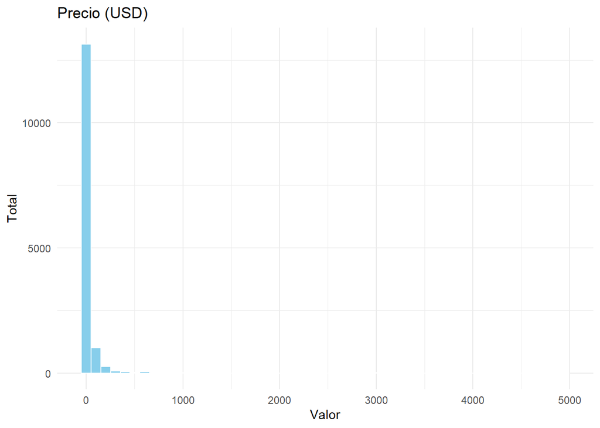

```r
ggplot(df, aes(x = PriceUSD)) +
  geom_histogram(bins = 50, fill = "skyblue", color = "white") +
  labs(title = "Precio (USD)", x = "Valor", y = "Total") +
  theme_minimal()
```

Observamos que la tendencia es a que la mayoría de precios tiendan a 0, lógico, ya que el precio *de una sola acción* no puede ser excesivamente alto. Sin embargo, parece que también tenemos precios que llegan a los miles de dólares. Esto lo podemos observar mejor utilizando una escala logarítmica en el eje de las X:

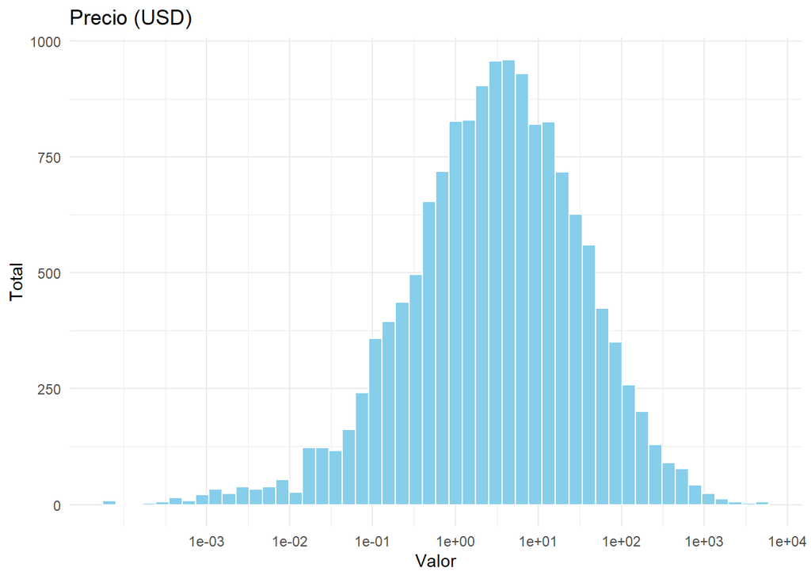

```r
ggplot(df, aes(x = PriceUSD)) +
  geom_histogram(bins = 50, fill = "skyblue", color = "white") +
  scale_x_log10(breaks = c(0.001, 0.01, 0.1, 1, 10, 100, 1000, 10000)) +
  labs(title = "Precio (USD)", x = "Valor", y = "Total") +
  theme_minimal()
```

La mayor concentración es, como podíamos esperar, cercana a la unidad / decena; mientras que podemos identificar casos extremos (por debajo de las 200 muestras), por debajo de ~0.05 dólares, y por encima de ~$500 dólares por acción.

Podemos mostrar estos casos extremos, con el fin de comprobar si son errores, que pueden haberse dado durante la fase de recolección de datos, o durante la de conversió; o si simplemente son particularidades de ciertos tipos de mercado:

```r
topn <- df %>%
  arrange(desc(PriceUSD)) %>%
  slice_head(n = 20) %>%
  select(Symbol, Country, PriceUSD, Sector)
topn
```

```
##    Symbol     Country PriceUSD                 Sector
## 1    BKNG         USA 4943.270      Consumer services
## 2    BKNG         USA 4943.270      Consumer services
## 3    BKNG         USA 4943.270      Consumer services
## 4    GIVN Switzerland 4336.934  Consumer non-durables
## 5    GIVN Switzerland 4336.934  Consumer non-durables
## 6    GIVN Switzerland 4336.934  Consumer non-durables
## 7     CSU      Canada 3027.576    Technology services
## 8     CSU      Canada 3027.576    Technology services
## 9     CSU      Canada 3027.576    Technology services
## 10   INRN Switzerland 2466.187 Producer manufacturing
## 11   INRN Switzerland 2466.187 Producer manufacturing
## 12   INRN Switzerland 2466.187 Producer manufacturing
## 13    RMS      France 2158.727  Consumer non-durables
## 14    RMS      France 2158.727  Consumer non-durables
## 15    RMS      France 2158.727  Consumer non-durables
## 16   MELI         USA 1872.010           Retail trade
## 17   MELI         USA 1872.010           Retail trade
## 18   MELI         USA 1872.010           Retail trade
## 19   COBH     Belgium 1722.389  Consumer non-durables
## 20   COBH     Belgium 1722.389  Consumer non-durables
```

```r
botn <- df %>%
  arrange(PriceUSD) %>%
  slice_head(n = 20) %>%
  select(Symbol, Country, PriceUSD, Sector)
botn
```

```
##        Symbol Country     PriceUSD            Sector
## 1        TGKA  Russia 6.661887e-05         Utilities
## 2        TGKA  Russia 6.661887e-05         Utilities
## 3        TGKA  Russia 6.661887e-05         Utilities
## 4        TGKB  Russia 6.932348e-05         Utilities
## 5        TGKB  Russia 6.932348e-05         Utilities
## 6        TGKB  Russia 6.932348e-05         Utilities
## 7        TGKN  Russia 7.506485e-05         Utilities
## 8        TGKN  Russia 7.506485e-05         Utilities
## 9        TGKN  Russia 7.506485e-05         Utilities
## 10 UNIVINSURE Nigeria 2.133161e-04           Finance
## 11 UNIVINSURE Nigeria 2.133161e-04           Finance
## 12 UNIVINSURE Nigeria 2.133161e-04           Finance
## 13   REGALINS Nigeria 3.102780e-04           Finance
## 14  GUINEAINS Nigeria 3.102780e-04           Finance
## 15   REGALINS Nigeria 3.102780e-04           Finance
## 16  GUINEAINS Nigeria 3.102780e-04           Finance
## 17   REGALINS Nigeria 3.102780e-04           Finance
## 18  GUINEAINS Nigeria 3.102780e-04           Finance
## 19 TANTALIZER Nigeria 3.619910e-04 Consumer services
## 20 TANTALIZER Nigeria 3.619910e-04 Consumer services
```

En el caso de los mayores precios, existe bastante variedad, tanto de países, como de sectores, así que no podemos garantizar que sean valores extremos. En el caso de los menores precios, los resultados sí parecen más concentrados (varias empresas en Rusia y Nigeria), y también los sectores (utilidades y finanzas). Sin embargo, no es suficiente para garantizar que sean datos errados, por lo que, si bien *sí son outliers* en nuestro conjunto, no podemos descartarlos.

### 2.4.2 `Volume` (en millones de unidades)

Como explicamos anteriormente, el volumen representa la cantidad de acciones de una empresa que hay en circulación en el mercado. En este juego de datos, lo presentamos en millones de unidades:

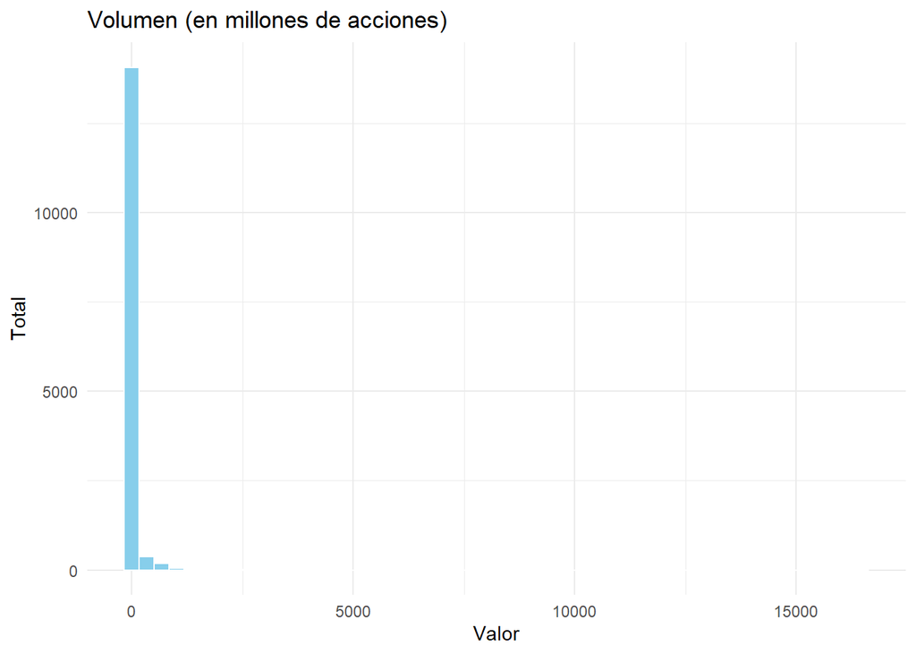

```r
ggplot(df, aes(x = Volume)) +
  geom_histogram(bins = 50, fill = "skyblue", color = "white") +
  labs(title = "Volumen (en millones de acciones)", x = "Valor", y = "Total") +
  theme_minimal()
```

Como en el caso de `Price`, mostraremos el resultado también en escala logarítmica, para analizar los posibles *outliers*:

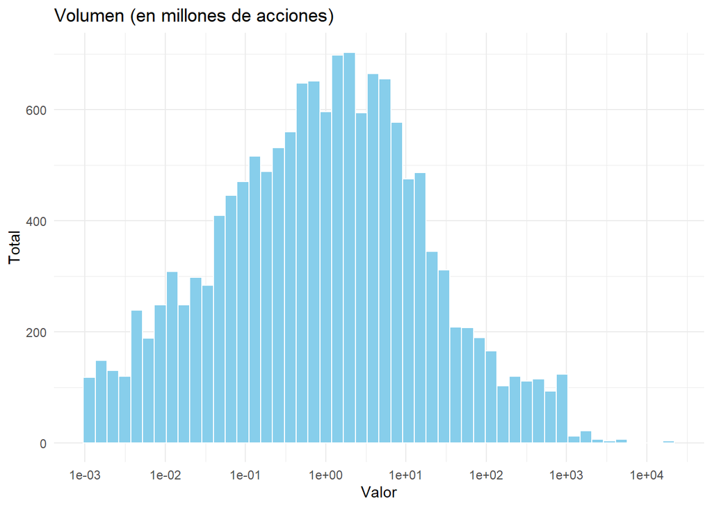

```r
ggplot(df, aes(x = Volume)) +
  geom_histogram(bins = 50, fill = "skyblue", color = "white") +
  scale_x_log10(breaks = c(0.0001, 0.001, 0.01, 0.1, 1, 10, 100, 1000, 10000)) +
  labs(title = "Volumen (en millones de acciones)", x = "Valor", y = "Total") +
  theme_minimal()
```

Obtenemos unos resultados relativamente más homogéneos, centrados en el millón de unidades, con posibles *outliers* cuando bajamos de las 10.000 acciones, y cuando superamos las 100 millones. De forma paralela al caso anterior, volveremos a mostrar estos registros, por si vemos algún patrón sospechoso:

```r
topn <- df %>%
  arrange(desc(Volume)) %>%
  slice_head(n = 20) %>%
  select(Symbol, Country, PriceUSD, Volume, Sector)
topn
```

```
##    Symbol   Country     PriceUSD Volume              Sector
## 1    TGKN    Russia 7.506485e-05  16460           Utilities
## 2    TGKN    Russia 7.506485e-05  16460           Utilities
## 3    TGKN    Russia 7.506485e-05  16460           Utilities
## 4    TGKA    Russia 6.661887e-05   4544           Utilities
## 5    TGKA    Russia 6.661887e-05   4544           Utilities
## 6    TGKA    Russia 6.661887e-05   4544           Utilities
## 7  600221     China 3.055088e-01   4462      Transportation
## 8  600221     China 3.055088e-01   4462      Transportation
## 9  600221     China 3.055088e-01   4462      Transportation
## 10   FEES    Russia 7.415382e-04   3648           Utilities
## 11   FEES    Russia 7.415382e-04   3648           Utilities
## 12   FEES    Russia 7.415382e-04   3648           Utilities
## 13   GOTO Indonesia 3.885998e-03   2206 Technology services
## 14   GOTO Indonesia 3.885998e-03   2206 Technology services
## 15   GOTO Indonesia 3.885998e-03   2206 Technology services
## 16    LTM     Chile 1.329594e-02   2066      Transportation
## 17    LTM     Chile 1.329594e-02   2066      Transportation
## 18    LTM     Chile 1.329594e-02   2066      Transportation
## 19 600010     China 3.013988e-01   1913 Non-energy minerals
## 20 600010     China 3.013988e-01   1913 Non-energy minerals
```

```r
botn <- df %>%
  arrange(Volume) %>%
  slice_head(n = 20) %>%
  select(Symbol, Country, PriceUSD, Volume, Sector)
botn
```

```
##        Symbol    Country     PriceUSD Volume              Sector
## 1         MER    Austria  0.647200544      0 Commercial services
## 2       REINI Luxembourg 27.349442364      0             Finance
## 3        VLCN Luxembourg 15.344916135      0           Utilities
## 4       GPINA Luxembourg  0.665000000      0             Finance
## 5        RTLL Luxembourg 29.750347609      0   Consumer services
## 6   CARACOLTV   Colombia  0.182935154      0   Consumer services
## 7  GASORIENTE   Colombia  0.302616610      0           Utilities
## 8  INCASTILLA   Colombia  4.819112628      0  Process industries
## 9  RIOPAILIND   Colombia  2.548350398      0  Process industries
## 10    BBVACOL   Colombia  0.039590444      0             Finance
## 11   RIOPAILA   Colombia  2.562002275      0  Process industries
## 12        BMC   Colombia  0.443686007      0             Finance
## 13   MAYAGUEZ   Colombia  3.321956769      0  Process industries
## 14 DESCAUCANO   Colombia  1.230944255      0 Commercial services
## 15   EMPAQUES   Colombia  3.344709898      0  Process industries
## 16      MARLY   Colombia  1.934015927      0     Health services
## 17    MINEROS   Colombia  0.831626849      0 Non-energy minerals
## 18   ELCONDOR   Colombia  0.136518771      0 Industrial services
## 19  CORFERIAS   Colombia  0.204778157      0 Commercial services
## 20     PAZRIO   Colombia  0.001114903      0 Non-energy minerals
```

En el top de acciones por volumen, volvemos a observar variedad, por lo que no son valores que debamos tratar. De hecho, obtenemos resultados compatibles con los que obteníamos anteriormente: ciertas acciones rusas, que tenían un precio de mercado excepcionalmente bajo, muestran un muy alto volumen de acciones, compensándose.

Sin embargo, en el orden contrario, observamos algo interesante: tenemos varias acciones con volumen de mercado igual a 0. Esto puede deberse a varios motivos, que no necesariamente señalarían un error en los datos, pero, a efectos de este trabajo, se escapa del alcance. Si analizamos cuántos registros muestran esta situación:

```r
sum(df$Volume == 0, na.rm = TRUE)
```

```
## [1] 84
```

No son una cantidad relevante, así que simplemente nos desharemos de ellas:

```r
df <- df[df$Volume != 0,]

botn <- df %>%
  arrange(Volume) %>%
  slice_head(n = 20) %>%
  select(Symbol, Country, PriceUSD, Volume, Sector)
botn
```

```
##    Symbol  Country   PriceUSD   Volume              Sector
## 1    HYSG  Belgium   3.570042 0.001000 Technology services
## 2     MLC  Ireland   6.054457 0.001000   Health technology
## 3    HYSG  Belgium   3.570042 0.001000 Technology services
## 4     MLC  Ireland   6.054457 0.001000   Health technology
## 5    HYSG  Belgium   3.570042 0.001000 Technology services
## 6     MLC  Ireland   6.054457 0.001000   Health technology
## 7   MLFMV Portugal   1.565808 0.001003             Finance
## 8   MLFMV Portugal   1.565808 0.001003             Finance
## 9   MLFMV Portugal   1.565808 0.001003             Finance
## 10 EGNETY  Denmark  18.892520 0.001005             Finance
## 11 EGNETY  Denmark  18.892520 0.001005             Finance
## 12 EGNETY  Denmark  18.892520 0.001005             Finance
## 13    MDP  Morocco   2.025151 0.001019  Process industries
## 14    MDP  Morocco   2.025151 0.001019  Process industries
## 15    MDP  Morocco   2.025151 0.001019  Process industries
## 16   480S    Spain  12.004526 0.001045 Technology services
## 17   480S    Spain  12.004526 0.001045 Technology services
## 18   480S    Spain  12.004526 0.001045 Technology services
## 19   VSMO   Russia 232.881342 0.001053 Non-energy minerals
## 20   VSMO   Russia 232.881342 0.001053 Non-energy minerals
```

### 2.4.3 `MarketCap` (en millones de dólares)

La capitalización de mercado de una empresa nos señala su dimensión económica, esto es, cuanto más alto sea, con mayor capital puede trabajar dicha empresa. Usaremos la variable `MarketCapUSD`, que tiene el valor normalizado en millones de dólares:

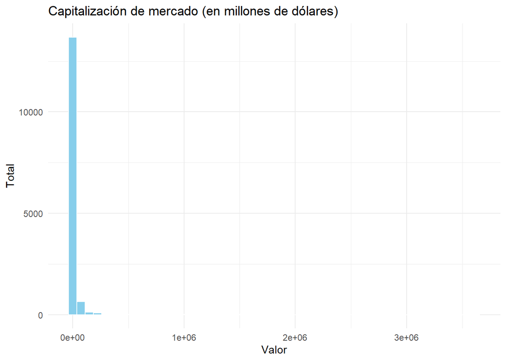

```r
ggplot(df, aes(x = MarketCapUSD)) +
  geom_histogram(bins = 50, fill = "skyblue", color = "white") +
  labs(title = "Capitalización de mercado (en millones de dólares)", x = "Valor", y = "Total") +
  theme_minimal()
```

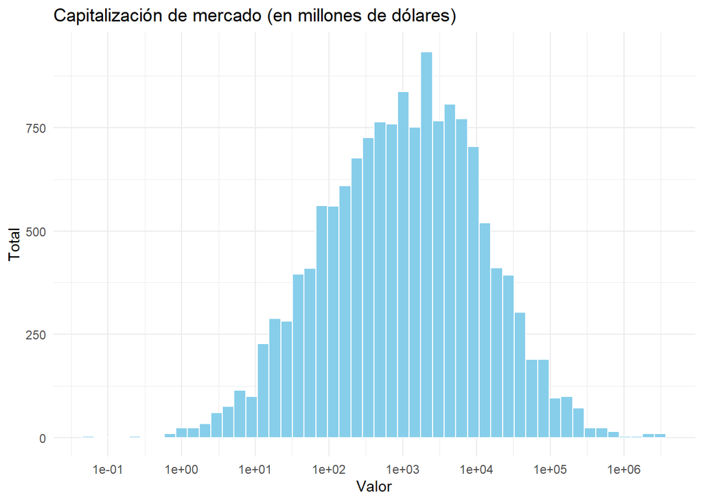

```r
ggplot(df, aes(x = MarketCapUSD)) +
  geom_histogram(bins = 50, fill = "skyblue", color = "white") +
  scale_x_log10(breaks = c(0.0001, 0.001, 0.01, 0.1, 1, 10, 100, 1000, 10000, 100000, 1000000)) +
  labs(title = "Capitalización de mercado (en millones de dólares)", x = "Valor", y = "Total") +
  theme_minimal()
```

Volvemos a obtener, con escala logarítmica, una forma normal, centrada en los ~1000M de dólares. Llaman la atención los valores inferiores: parece que puede haber registros con un `MarketCap` igual a 0:

```r
botn <- df %>%
  arrange(MarketCapUSD) %>%
  slice_head(n = 20) %>%
  select(Country, PriceUSD, Volume, MarketCapUSD, Sector)
botn
```

```
##         Country    PriceUSD     Volume MarketCapUSD                 Sector
## 1        Cyprus 0.003131616   0.005000   0.06340478                Finance
## 2        Cyprus 0.003131616   0.005000   0.06340478                Finance
## 3        Cyprus 0.003131616   0.005000   0.06340478                Finance
## 4  South Africa 6.169702876   0.049299   0.23759204  Distribution services
## 5  South Africa 6.169702876   0.049299   0.23759204  Distribution services
## 6  South Africa 6.169702876   0.049299   0.23759204  Distribution services
## 7       Belgium 0.294893796   0.045640   0.59053918      Health technology
## 8       Belgium 0.294893796   0.045640   0.59053918      Health technology
## 9       Belgium 0.294893796   0.045640   0.59053918      Health technology
## 10        Kenya 0.001622024   0.037600   0.59197703           Retail trade
## 11        Kenya 0.001622024   0.037600   0.59197703           Retail trade
## 12        Kenya 0.001622024   0.037600   0.59197703           Retail trade
## 13       Cyprus 0.002609680   0.330000   0.75195517                Finance
## 14       Cyprus 0.002609680   0.330000   0.75195517                Finance
## 15       Cyprus 0.002609680   0.330000   0.75195517                Finance
## 16        Kenya 0.022399381   0.010100   0.89597525 Producer manufacturing
## 17        Kenya 0.022399381   0.010100   0.89597525 Producer manufacturing
## 18        Kenya 0.022399381   0.010100   0.89597525 Producer manufacturing
## 19    Venezuela 0.187423417 295.000000   0.98545260 Producer manufacturing
## 20    Venezuela 0.187423417 295.000000   0.98545260 Producer manufacturing
```

# 3 Análisis de datos

## 3.1 Modelo supervisado

(…)

## 3.2 Modelo no supervisado

> Mi idea aquí es hacer quizá K-Means, pero sospecho que habrá que simplificar las categorías de `Sector`

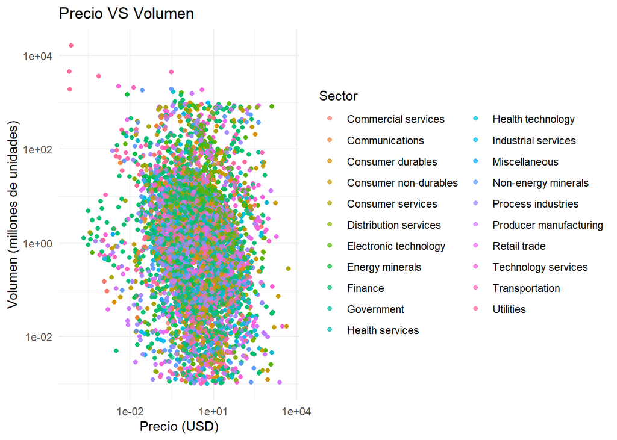

```r
ggplot(df, aes(x = PriceUSD, y = Volume, color = Sector)) +
  geom_point(alpha = 0.7) +
  scale_x_log10() +
  scale_y_log10() +
  labs(title = "Precio VS Volumen", x = "Precio (USD)", y = "Volumen (millones de unidades)") +
  theme_minimal()
```